# 17.1_k_means_hierachical

## In K-means clustering, we seek to partition the observations into a pre-specified number of clusters.

- K-means clustering is a simple and elegant approach for partitioning a data set into K distinct, non-overlapping clusters. To perform K-means clustering, **we must first specify the desired number of clusters K;** then the K-means algorithm will assign each observation to exactly one of the K clusters.
- If the $i_{th}$ observation is in the $k_{th}$ cluster, then $i \space \epsilon \space C_k$. The idea behind K-means clustering is that a good clustering is one for which the within-cluster variation is as small as possible.
  - Measure of within-cluster variation: $ \sum_{i=1}^n (x_{i}^{(j)} - c_j)^2 $ - squared euclidean distance measure between a data point $x_{i}^{(j)}$ and the cluster centre $c_j$, n - datapoints in $j_{th}$ cluster
- In words, below formula says that we want to **partition the observations into K clusters such that the "total within-cluster variation, summed over all K clusters" (WCSS), is as small as possible.** $$ minimize \sum_{j=1}^k \sum_{i=1}^n (x_{i}^{(j)} - c_j)^2 $$

### "How to choose K ?" - One way to determine the number of clusters is to look at how the total of "within cluster sum of squares (WCSS)" behaves when the number of cluster changes. When you plot the number of clusters and the total WCSS (elbow-curve), the optimal number of clusters is when the total WCSS drops radically. We can access this value using "sklearn.cluster.KMeans.inertia_" attribute.

## K-Means Clustering Alogrithm:

- 1) Randomly assign a number, from 1 to K, to each of the observations.These serve as initial cluster assignments for the observations.
- 2) Iterate until the cluster assignments stop changing:
  - (a) For each of the K clusters, compute the cluster centroid. The $k_{th}$ cluster centroid is the vector of the p feature means for the observations in the $k_{th}$ cluster.
  - (b) Assign each observation to the cluster whose centroid is closest (where closest is defined using Euclidean distance).

### K-means++ : is just an initialization procedure for K-means. K-means++ will initialize with optimal centroids. This will reduce number of iterations in finding the clusters.

```python
import pandas as pd
import numpy as np
import matplotlib.pyplot as plt
% matplotlib inline
from sklearn.base import BaseEstimator, TransformerMixin
from sklearn.pipeline import Pipeline
```

```python
housing_train_set = pd.read_csv('../data/cleaned_housing_train_set.csv')
X_features  = [feature for feature in housing_train_set.columns if feature not in ['SalePrice', 'Id']]
y_feature = 'SalePrice'
```

```python
class InputOutputFeatureSelector(BaseEstimator, TransformerMixin):
    def __init__(self, in_attr_list, our_feature):
        self.in_attr_list = in_attr_list
        self.our_feature = our_feature
    def fit(self, X, y=None):
        return self
    def transform(self, X):
        return X[self.in_attr_list].values, X[self.our_feature].values
```

```python
pipeline_inout_features = Pipeline([
    ('inputOutputFeatureSelector', InputOutputFeatureSelector(X_features, y_feature))
])
```

```python
X_train, y_train = pipeline_inout_features.transform(housing_train_set)
```

```python
X_train.shape
```

```
(1149, 98)
```

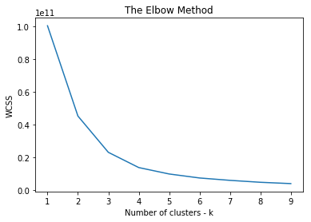

```python
from sklearn.cluster import KMeans

wcss = [] # Within Cluster Sum of Squares
for k in range(1, 10):
    kmeans = KMeans(n_clusters = k, init = 'k-means++', random_state = 42)
    kmeans.fit(X_train)
    wcss.append(kmeans.inertia_)
plt.plot(range(1, 10), wcss)
plt.title('The Elbow Method')
plt.xlabel('Number of clusters - k')
plt.ylabel('WCSS')
plt.show()
```

```python
best_kmeans = KMeans(n_clusters = 4, init = 'k-means++', random_state = 42)
X_clusters = best_kmeans.fit_predict(X_train)
```

```python
X_clusters.shape
```

```
(1149,)
```

```python
X_clusters[:100]
```

```
array([0, 2, 0, 2, 0, 0, 2, 1, 2, 3, 2, 3, 2, 2, 2, 0, 3, 1, 0, 2, 0, 2, 0,
       2, 1, 2, 0, 2, 0, 0, 2, 2, 2, 2, 2, 2, 0, 0, 0, 1, 0, 2, 1, 0, 2, 0,
       0, 3, 3, 1, 0, 1, 0, 2, 0, 1, 2, 2, 0, 2, 2, 2, 2, 2, 0, 0, 2, 0, 0,
       3, 1, 2, 2, 2, 0, 0, 2, 1, 2, 2, 2, 0, 0, 1, 1, 1, 2, 0, 3, 2, 0, 2,
       3, 0, 2, 2, 2, 0, 1, 2])
```

```python
X_clusters = X_clusters.reshape(-1,1)
```

```python
X_train = np.c_[(X_train,X_clusters )]
```

```python
X_train.shape
```

[output not shown]

```python
from sklearn.preprocessing import MinMaxScaler
min_max = MinMaxScaler(feature_range=(-1,1))
X_train = min_max.fit_transform(X_train)
```

### Build SGDModel and see if preformance improves.

```python
from sklearn.linear_model import SGDRegressor
sgd_model = SGDRegressor()
sgd_model.fit(X_train, y_train)
```

```
SGDRegressor(alpha=0.0001, average=False, epsilon=0.1, eta0=0.01,
       fit_intercept=True, l1_ratio=0.15, learning_rate='invscaling',
       loss='squared_loss', n_iter=5, penalty='l2', power_t=0.25,
       random_state=None, shuffle=True, verbose=0, warm_start=False)
```

```python
from sklearn.metrics import mean_squared_error, r2_score
pred_X_train = sgd_model.predict(X_train)
mse_X_train =  mean_squared_error(y_train, pred_X_train)
r2_X_train = r2_score(y_train, pred_X_train)
print('Root Mean Squared Error X Train : ', np.sqrt(mse_X_train))
print('R-Squre X Train : ', r2_X_train)
```

```
Root Mean Squared Error X Train :  34495.5835558
R-Squre X Train :  0.823680345324
```